# burnout_datacleaning

Rachel Brynsvold

7/30/2021

## Read in, view

```r
#read in data
library(readr)
burnout_orig = read_csv("train.csv")
#create copy to edit
burnout_cl = burnout_orig

#check structure of as-read
str(burnout_orig)
```

```
## spec_tbl_df [22,750 × 9] (S3: spec_tbl_df/tbl_df/tbl/data.frame)
##  $ Employee ID         : chr [1:22750] "fffe32003000360033003200" "fffe3700360033003500" "fffe31003300320037003900" "fffe32003400380032003900" ...
##  $ Date of Joining     : Date[1:22750], format: "2008-09-30" "2008-11-30" ...
##  $ Gender              : chr [1:22750] "Female" "Male" "Female" "Male" ...
##  $ Company Type        : chr [1:22750] "Service" "Service" "Product" "Service" ...
##  $ WFH Setup Available : chr [1:22750] "No" "Yes" "Yes" "Yes" ...
##  $ Designation         : num [1:22750] 2 1 2 1 3 2 3 2 3 3 ...
##  $ Resource Allocation : num [1:22750] 3 2 NA 1 7 4 6 4 6 6 ...
##  $ Mental Fatigue Score: num [1:22750] 3.8 5 5.8 2.6 6.9 3.6 7.9 4.4 NA NA ...
##  $ Burn Rate           : num [1:22750] 0.16 0.36 0.49 0.2 0.52 0.29 0.62 0.33 0.56 0.67 ...
##  - attr(*, "spec")=
##   .. cols(
##   ..   `Employee ID` = col_character(),
##   ..   `Date of Joining` = col_date(format = ""),
##   ..   Gender = col_character(),
##   ..   `Company Type` = col_character(),
##   ..   `WFH Setup Available` = col_character(),
##   ..   Designation = col_double(),
##   ..   `Resource Allocation` = col_double(),
##   ..   `Mental Fatigue Score` = col_double(),
##   ..   `Burn Rate` = col_double()
##   .. )
```

## Examine, clean each field

#### `Employee ID`

Index field, no action necessary

#### `Date of joining`

Already date formatted; below is code (not evaluated) for a `Days in Org'` field if needed in the future

```r
#ran model with `Days in Org` and with `Date of Joining` and got same results
#so not adding, but wanted to leave the code in case we do find we want it for some reason

#dataset goes from 1/1/2008 to 12/31/2008
min(burnout_orig$"Date of Joining")
max(burnout_orig$"Date of Joining")

end_date = max(burnout_orig$"Date of Joining")
#min(burnout_orig$"Date of Joining")

burnout_cl$"Days in Org" = as.numeric(end_date -
                                        burnout_orig$"Date of Joining")
burnout_cl$"Days in Org"[1:24]

hist(burnout_cl$"Date of Joining", col = "lightblue",
     main = "Histogram of Date of Joining field",
     breaks = 'months',
     xlab = "Date of Joining" )
```

#### `Gender`

Only 2 unique values; should be a factor

```r
unique(burnout_orig$"Gender")
```

```
## [1] "Female" "Male"
```

```r
is.factor(burnout_orig$"Gender")
```

```
## [1] FALSE
```

```r
burnout_cl$"Gender" = as.factor(burnout_orig$"Gender")
is.factor(burnout_cl$"Gender")
```

```
## [1] TRUE
```

#### `Company Type`

Only 2 unique values; should be a factor

```r
unique(burnout_orig$"Company Type")
```

```
## [1] "Service" "Product"
```

```r
is.factor(burnout_orig$"Company Type")
```

```
## [1] FALSE
```

```r
burnout_cl$"Company Type" = as.factor(burnout_orig$"Company Type")
is.factor(burnout_cl$"Company Type")
```

```
## [1] TRUE
```

#### `WFH Setup Available`

Only 2 unique values; should be a factor

```r
unique(burnout_orig$"WFH Setup Available")
```

```
## [1] "No"  "Yes"
```

```r
is.factor(burnout_orig$"WFH Setup Available")
```

```
## [1] FALSE
```

```r
burnout_cl$"WFH Setup Available" = as.factor(burnout_orig$"WFH Setup Available")
is.factor(burnout_cl$"WFH Setup Available")
```

```
## [1] TRUE
```

```r
#TODO - decide
#consider changing levels so Yes = 2?
#as.numeric(burnout_cl$"WFH Setup Available")
#does not dictate the positive class though
```

The remainder of the fields are all numerical values where, per the data dictionary, the values (whether continuous or integer) exist on a scale (eg higher Designation value translates to higher in the organization). Therefore, for these fields we will be checking distributions and examining/handling NA’s.

#### `Designation`

No NA’s; no cleaning action needed

```r
unique(burnout_orig$"Designation")
```

```
## [1] 2 1 3 0 4 5
```

```r
sum(is.na(burnout_orig$"Designation"))
```

```
## [1] 0
```

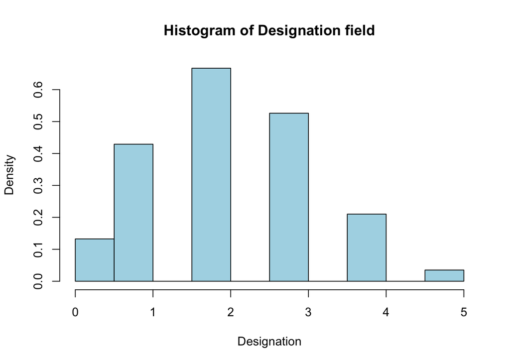

```r
hist(burnout_cl$"Designation", col = "lightblue", probability = TRUE,
     main = "Histogram of Designation field",
     xlab = "Designation" )
```

#### `Resource Allocation`

Proportion of NA’s deemed acceptable for modeling

```r
sum(is.na(burnout_orig$"Resource Allocation"))
```

```
## [1] 1381
```

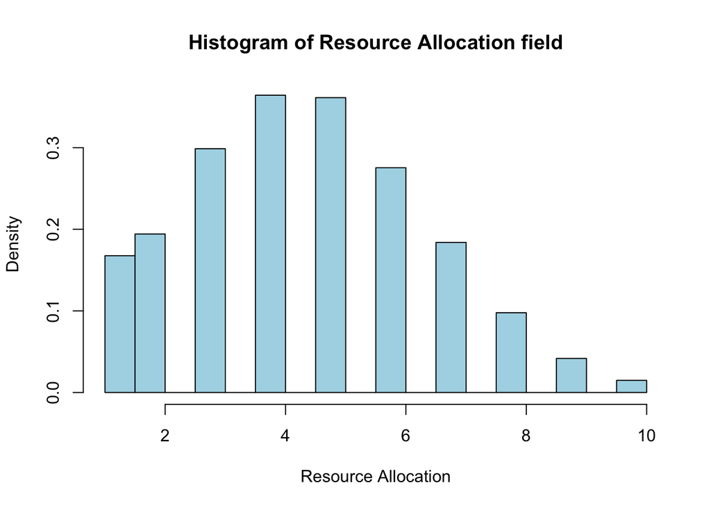

```r
ra_na_proportion = sum(is.na(burnout_orig$"Resource Allocation")) /
                            nrow(burnout_orig)

hist(burnout_cl$"Resource Allocation", col = "lightblue", probability = TRUE,
     main = "Histogram of Resource Allocation field",
     xlab = "Resource Allocation")
```

6.07% of `Resource Allocation` values are NA.

#### `Mental Fatigue Score`

Proportion of NA’s deemed acceptable for modeling

```r
sum(is.na(burnout_orig$"Mental Fatigue Score"))
```

```
## [1] 2117
```

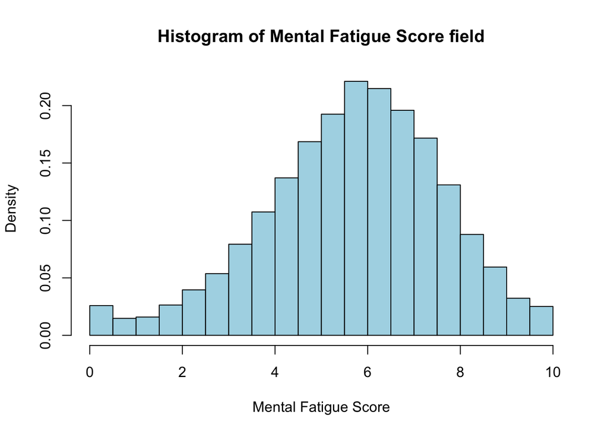

```r
mf_na_proportion = sum(is.na(burnout_orig$"Mental Fatigue Score")) /
                            nrow(burnout_orig)

hist(burnout_cl$"Mental Fatigue Score", col = "lightblue", probability = TRUE,
     main = "Histogram of Mental Fatigue Score field",
     xlab = "Mental Fatigue Score")
```

9.31% of `Mental Fatigue Score` values are NA.

#### `Burn Rate`

Records with no target value for the target field are of no use for training.  
Should drop these records.

```r
sum(is.na(burnout_orig$"Burn Rate"))
```

```
## [1] 1124
```

```r
br_na_proportion = sum(is.na(burnout_orig$"Burn Rate")) /
                            nrow(burnout_orig)
```

4.94% of `Burn Rate` values are NA.

```r
#I've dropped these vals, but lm will drop any fields containing null by default
#conceptually it seems important to drop, but practically it makes no difference,
#and changing the length of the dataset could cause headaches down the line

burnout_cl = burnout_cl[!is.na(burnout_orig$"Burn Rate"), ]
#confirm drop
sum(is.na(burnout_cl$"Burn Rate"))
```

```
## [1] 0
```

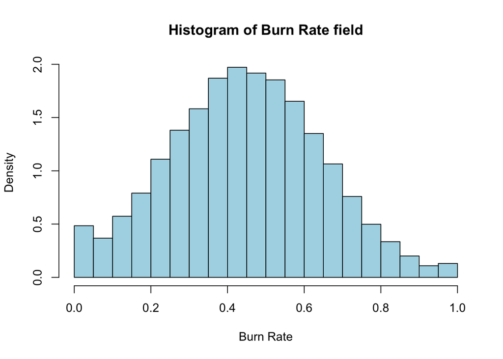

```r
hist(burnout_cl$"Burn Rate", col = "lightblue", probability = TRUE,
     main = "Histogram of Burn Rate field",
     xlab = "Burn Rate")
```

## Cleaning Wrap-up

After dropping the records with `Burn Rate` NA, we should recalculate the NA proportions we calculated above.

```r
recalc_mf_na_proportion = sum(is.na(burnout_cl$"Mental Fatigue Score")) /
                            nrow(burnout_cl)
recalc_ra_na_proportion = sum(is.na(burnout_cl$"Resource Allocation")) /
                            nrow(burnout_cl)
```

After dropping, 5.91% of `Resource Allocation` values are NA.  
After dropping, 8.99% of `Mental Fatigue Score` values are NA.

Final look at the cleaned dataset:

```r
str(burnout_cl)
```

```
## tibble [21,626 × 9] (S3: tbl_df/tbl/data.frame)
##  $ Employee ID         : chr [1:21626] "fffe32003000360033003200" "fffe3700360033003500" "fffe31003300320037003900" "fffe32003400380032003900" ...
##  $ Date of Joining     : Date[1:21626], format: "2008-09-30" "2008-11-30" ...
##  $ Gender              : Factor w/ 2 levels "Female","Male": 1 2 1 2 1 2 1 1 1 1 ...
##  $ Company Type        : Factor w/ 2 levels "Product","Service": 2 2 1 2 2 1 2 2 2 1 ...
##  $ WFH Setup Available : Factor w/ 2 levels "No","Yes": 1 2 2 2 1 2 1 2 1 1 ...
##  $ Designation         : num [1:21626] 2 1 2 1 3 2 3 2 3 3 ...
##  $ Resource Allocation : num [1:21626] 3 2 NA 1 7 4 6 4 6 6 ...
##  $ Mental Fatigue Score: num [1:21626] 3.8 5 5.8 2.6 6.9 3.6 7.9 4.4 NA NA ...
##  $ Burn Rate           : num [1:21626] 0.16 0.36 0.49 0.2 0.52 0.29 0.62 0.33 0.56 0.67 ...
```

```r
#running a basic model to check that cleaning yielded a usable dataset
#use na.exclude to handle remaining NA's (reference: https://stats.stackexchange.com/questions/492955/should-i-use-na-omit-or-na-exclude-in-a-linear-model-in-r)

test = lm(`Burn Rate` ~ `Date of Joining` + Gender + `Company Type` + `WFH Setup Available`
                + Designation + `Resource Allocation` + `Mental Fatigue Score`,
   data = burnout_cl, na.action = na.exclude)
summary(test)
```

```
##
## Call:
## lm(formula = `Burn Rate` ~ `Date of Joining` + Gender + `Company Type` +
##     `WFH Setup Available` + Designation + `Resource Allocation` +
##     `Mental Fatigue Score`, data = burnout_cl, na.action = na.exclude)
##
## Residuals:
##      Min       1Q   Median       3Q      Max
## -0.15670 -0.04101 -0.00033  0.04053  0.20203
##
## Coefficients:
##                            Estimate Std. Error t value Pr(>|t|)
## (Intercept)              -7.632e-02  5.463e-02  -1.397    0.162
## `Date of Joining`        -6.290e-07  3.883e-06  -0.162    0.871
## GenderMale                4.441e-03  8.288e-04   5.358 8.50e-08 ***
## `Company Type`Service     4.784e-04  8.600e-04   0.556    0.578
## `WFH Setup Available`Yes -1.157e-02  8.599e-04 -13.459  < 2e-16 ***
## Designation              -4.761e-03  7.547e-04  -6.309 2.88e-10 ***
## `Resource Allocation`     2.860e-02  5.053e-04  56.606  < 2e-16 ***
## `Mental Fatigue Score`    7.388e-02  3.564e-04 207.286  < 2e-16 ***
## ---
## Signif. codes:  0 '***' 0.001 '**' 0.01 '*' 0.05 '.' 0.1 ' ' 1
##
## Residual standard error: 0.05574 on 18582 degrees of freedom
##   (3036 observations deleted due to missingness)
## Multiple R-squared:  0.9207, Adjusted R-squared:  0.9206
## F-statistic: 3.081e+04 on 7 and 18582 DF,  p-value: < 2.2e-16
```

## Test write out/read back in

```r
#Does not read back in the same as it was written out
#It appears we need to preface the modeling script with a condensed version of
#this cleaning script (or set params on the read_csv call to make it match)

write_csv(burnout_cl, "train_cleaned.csv")
reread = read_csv("train_cleaned.csv")
all.equal(burnout_cl, reread)
```

```
## [1] "Attributes: < Length mismatch: comparison on first 2 components >"
## [2] "Attributes: < Component \"class\": Lengths (3, 4) differ (string compare on first 3) >"
## [3] "Attributes: < Component \"class\": 3 string mismatches >"
## [4] "Component \"Gender\": 'current' is not a factor"
## [5] "Component \"Company Type\": 'current' is not a factor"
## [6] "Component \"WFH Setup Available\": 'current' is not a factor"
```